# Tidyverse Introduction

Pietro Franceschi

17 May, 2021

# Introduction

This .Rmd file is a concise summary of a set of advanced R libraries and ideas which can be used for the analysis of large scale datasets.

In particular:

- Pipes (`%>%`)
- Tabular data
  - `data.frame`, `tibble`, `data.table`
  - data carpentry (`tidyverse`, `data.table`)
  - *long* and *wide* tables
  - modeling (`broom`)
- Vectorizing operations (`purrr`)

```r
library(tidyverse)     ## the full tidyverse ecosystem for seamless working with tables
library(broom)         ## a broom to tidy the outcomes of modeling
library(data.table)    ## a less flexible (bit more fast) approach to the manipulation of tabular data
```

# Piping

The overall idea behind piping is to make easy to read a chain of functions. Pipes `%>%` have been introduced in the `magrittr` package but are now a core tool of tidyverse

```r
## sequence going from 1 to the square root of 100
one_old <-seq(1,sqrt(100))

## The old style work have to be read in an "onion" fashion

one_pipe <- sqrt(100) %>%
  seq(1,.)

## one_old and one_pipe are exactly equivalent, but the second is by far more easy to read
```

When putting a function in a pile, you refer to “what is coming from the pipe” with a dot `.`

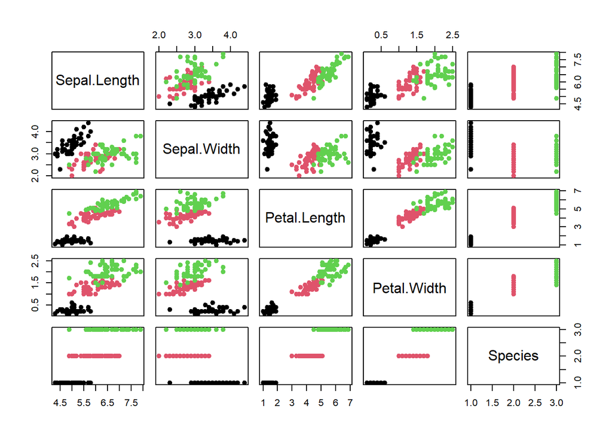

```r
## Pipes can be used also to produce plots!

data(iris) ## iris dataset

## note the dot to refer to the iris data.frame which reach the pairs function from the pipe
iris %>% pairs(., col = factor(iris$Species), pch = 19)
```

### Advantages

- Clear writing
- No need of cluttering the workspace with intermediate objects

### Disadvantages

- no big disadvantages, even if I normally rely on them when I use the console, while in programming tasks I prefer to rely on the “old” onion approach